# The rasterized-disk riddle: a ladder of ideas up to the provable best

## The puzzle

You drop a disk of **known radius** at a random spot on an infinite grid of unit squares. Every square the disk overlaps gets colored in. Then you throw the disk away and hand me only two things: the set of colored squares, and the radius.

**Where was the center?**

The colored squares don’t pin it down exactly — many nearby centers produce the *same* set of squares — so this is really a question about how *close* you can get, on average, over many random drops. Below is one such instance: the blue squares are what I get to see, and the dashed outline and green cross (the disk and its true center) are what I’m trying to recover.

What follows is a ladder of ideas, from a throwaway baseline up to a method that is **provably within a few percent of the best any algorithm could ever do** — with a short argument for why that best exists at all.

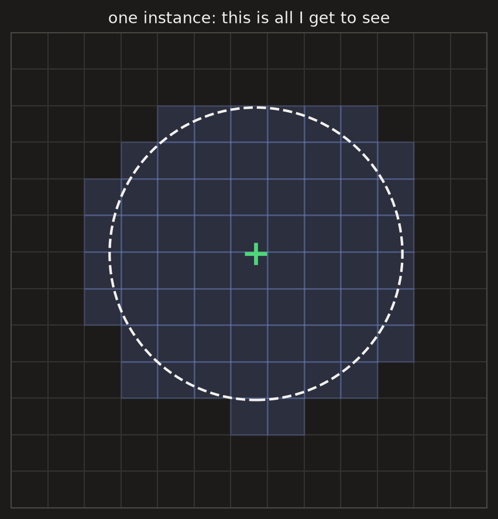

Throughout, the **green +** is the true center I’m hunting for, the **orange ×** is a method’s guess, and the dotted line between them is the error. Every idea below is run on this *same* disk so the pictures line up.

## The ladder, worst to best

### 1. Random — the “why bother” baseline

Ignore everything about the shape: just pick a random point somewhere inside the colored blob. This exists only to set the bar that every real idea has to clear.

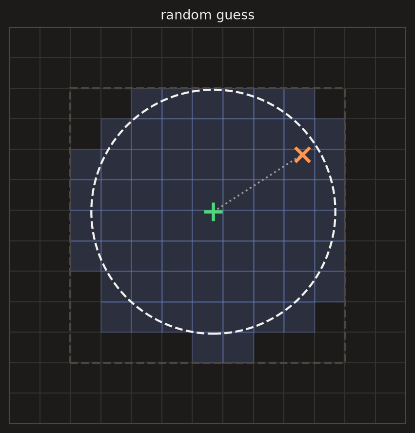

### 2. Bounding box — use the symmetry

A disk is symmetric left-to-right and top-to-bottom, so the middle of the smallest box enclosing the colored squares should sit right on the center. One clean idea, and it works — but it leans entirely on the four outermost squares and throws away everything in between. That’s also why it stops improving as the disk grows: extra interior squares tell it nothing.

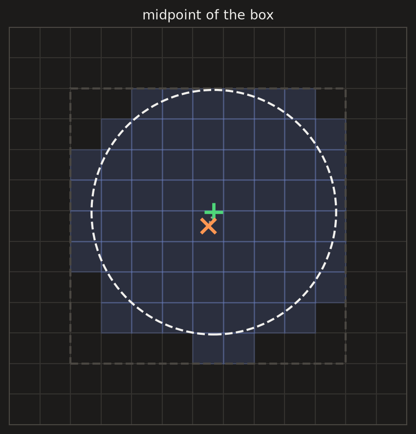

### 3. Boundary fit — the rim traces the circle

The outer rim of the colored blob is a fuzzy copy of the true circle. Since I know the radius, I can slide a circle of exactly that size around until its edge sits as evenly as possible on all the rim squares. Concretely this is a **Gauss-Newton least-squares fit**: it minimizes the total squared miss — the sum over rim squares of (distance from the guessed center to that square − radius)² — taking a handful of Newton steps from the centroid until the center stops moving. The dotted circle is the starting guess; the solid one is where it settles.

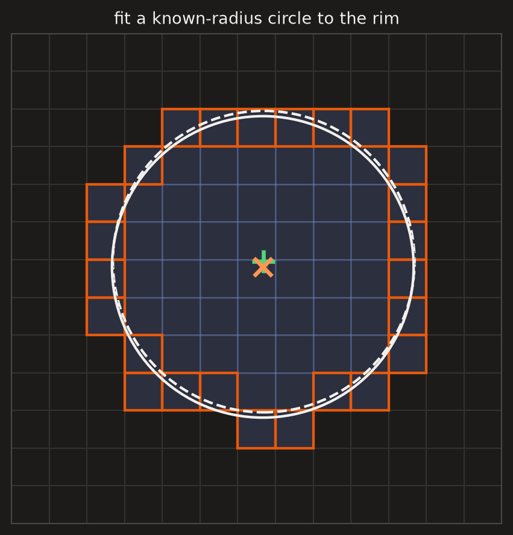

### 4. Centroid — average everything

Forget the rim; just average the centers of *all* the colored squares. Using every square makes it steadier than the bounding box. But there’s a subtle bias: a square gets colored if the disk touches it *at all*, so the coloring reaches slightly outward past the true circle, and the average drifts a hair outward with it.

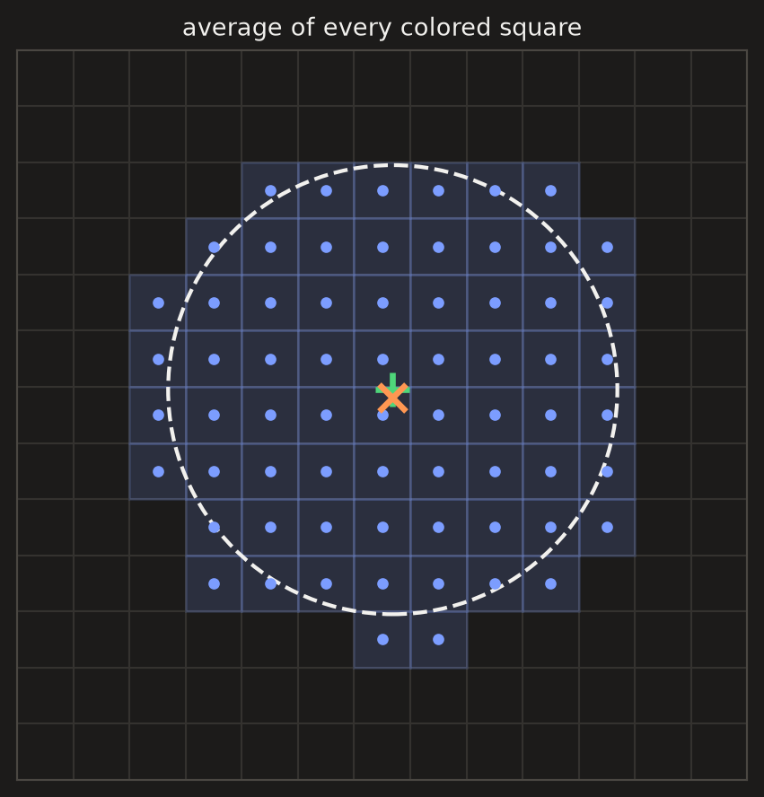

### 5. Interior-weighted centroid — trust the deep squares more

Fix the centroid’s outward drift by giving each square a vote equal to how many of its neighbors are also colored. Squares buried deep inside the disk vote hard; lonely squares out on the fuzzy rim barely vote at all. The number in each square is its vote; brighter squares pull harder.

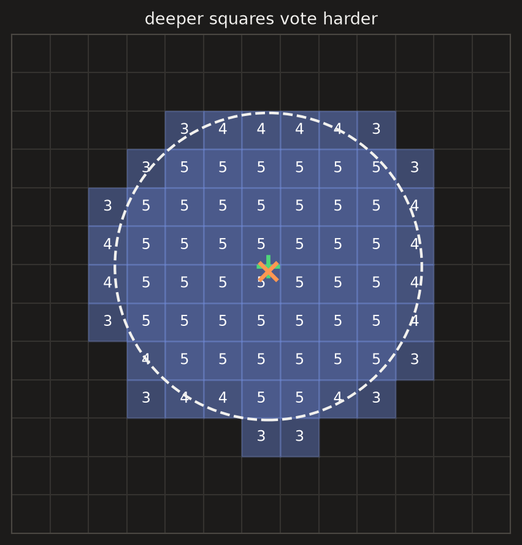

### 6. Template match — guess, redraw, compare

Turn the problem around. I already know the exact rule that turns a center into a set of colored squares, so I can *play it forward*: guess a center, draw the disk it would make, and see which squares disagree with what I actually observed. Then nudge the guess to shrink the disagreement, and repeat. Below, orange squares are ones the guess predicts but I didn’t see; pink squares are ones I saw but the guess missed — and both dwindle to almost nothing as the guess slides into place.

The quantity being minimized is exactly that count of disagreeing squares, and the “nudge” is a **pattern search** (coordinate descent): try one step north, south, east, or west, take the first that lowers the count, and when no direction helps, halve the step and look again — stopping once the step is tiny.

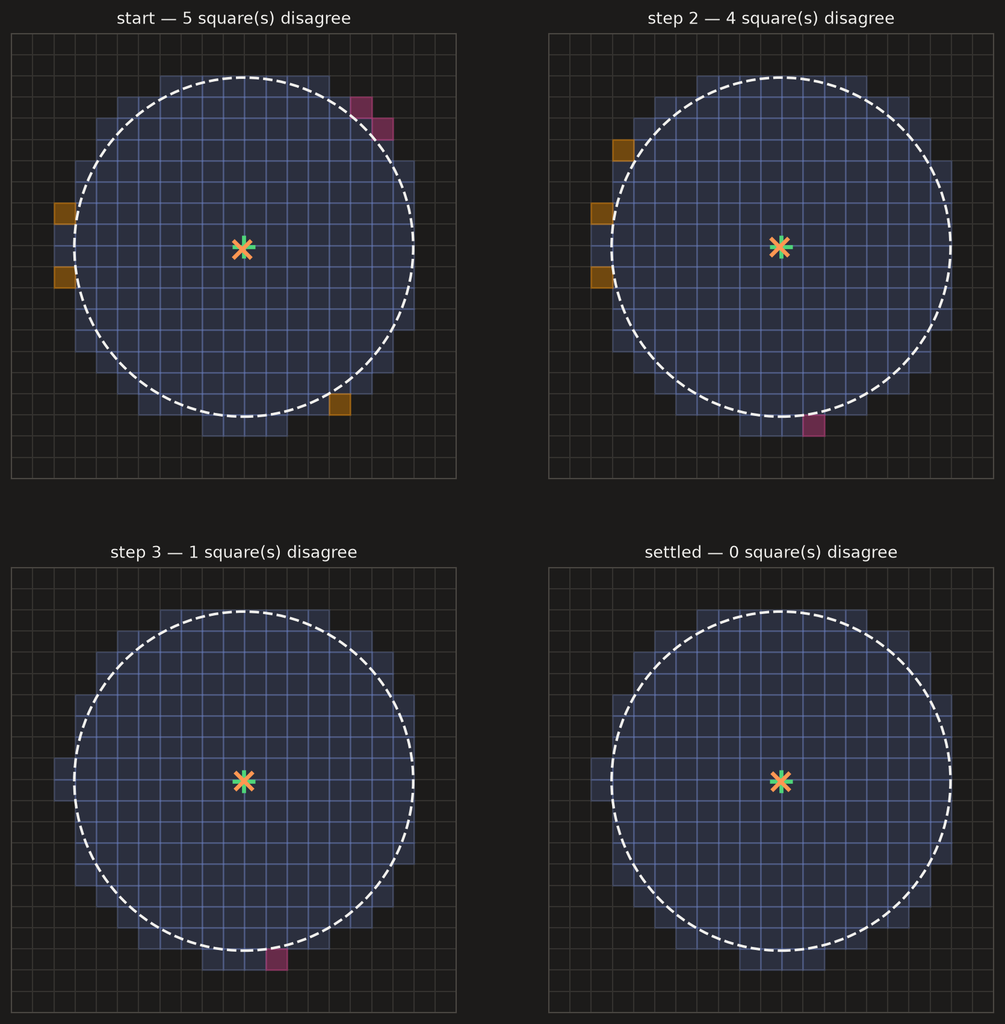

### 7. Medial-axis peak — the deepest point inside

A different intuition: the center should be the point *farthest from the edge* of the colored blob — the spot where the largest circle you can inscribe in the blob is centered. So walk uphill on one specific quantity: the radius of that inscribed circle, which is just the distance from your point to the nearest edge. “Uphill” is the same **compass hill-climb** as the pattern search above — step north, south, east, or west, keep any move that enlarges the inscribed radius, halve the step when none do — growing the purple circle as you go.

The neat thing: this is the only idea here that never uses the known radius, so it also solves the harder puzzle where the radius is a secret. The catch: “deepest point” is only a *stand-in* for the true center, not the same thing. On a big disk the rim flattens into a wide plateau of nearly-equal depth, the peak gets mushy, and the guess can drift — which is exactly why this method fades at large radii.

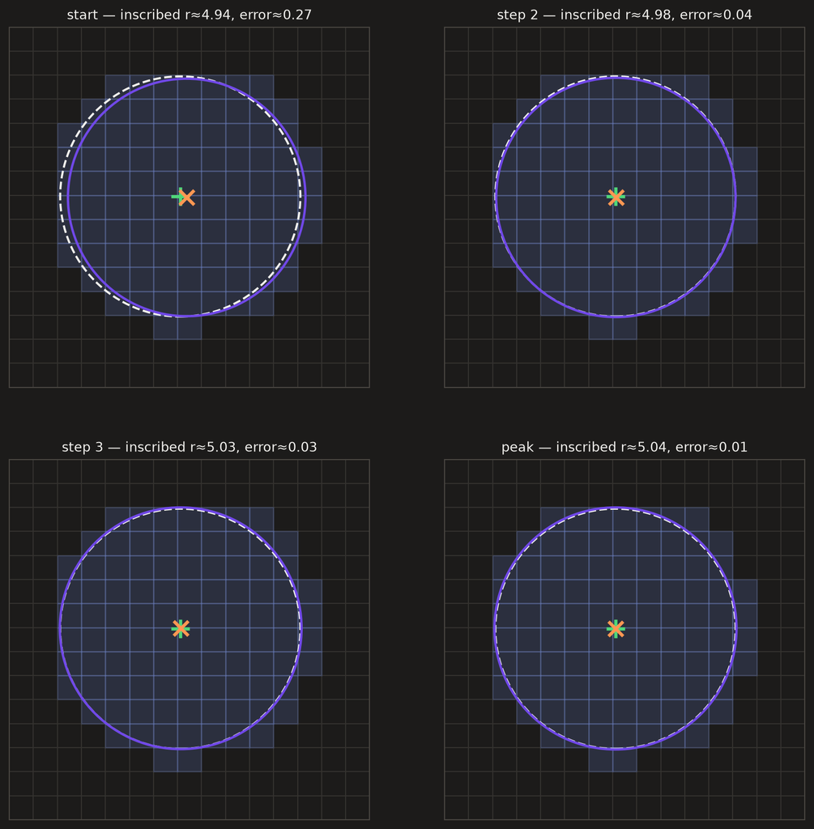

### 8. Feasible region — every center that’s still possible

The best idea drops guessing entirely and reasons about *constraints*. Take a corner of a colored square: the disk reached it, so the true center is within one radius of that corner (a green circle — center must be inside). Take a corner the disk missed: the center must be *more* than a radius away (a red circle — center must be outside). Pile up all these “inside this / outside that” constraints and they fence off a small pocket of the plane: *every* center consistent with what I saw, and nothing else. The answer is the middle of that pocket — reached by pattern-searching to the deepest point inside it, then averaging a fine grid of sample points that land within.

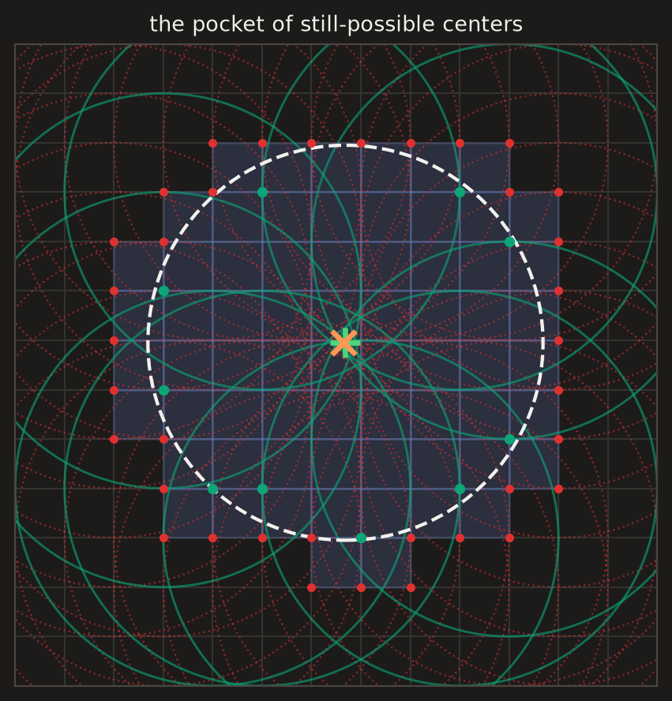

## Who actually wins

Time to stop eyeballing single pictures and run each idea over a thousand random drops per radius.

### Accuracy

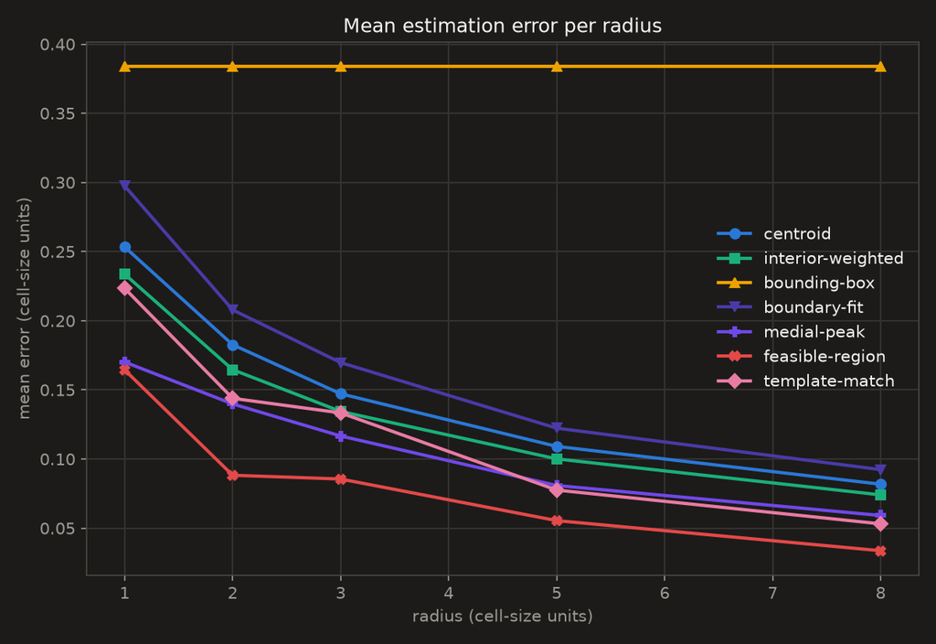

### Speed

Accuracy isn’t free. The simple averaging ideas run in microseconds; the ones that search — redraw-and-compare, walk-uphill, carve-the-pocket — re-check the geometry many times per answer and run hundreds to thousands of times slower.

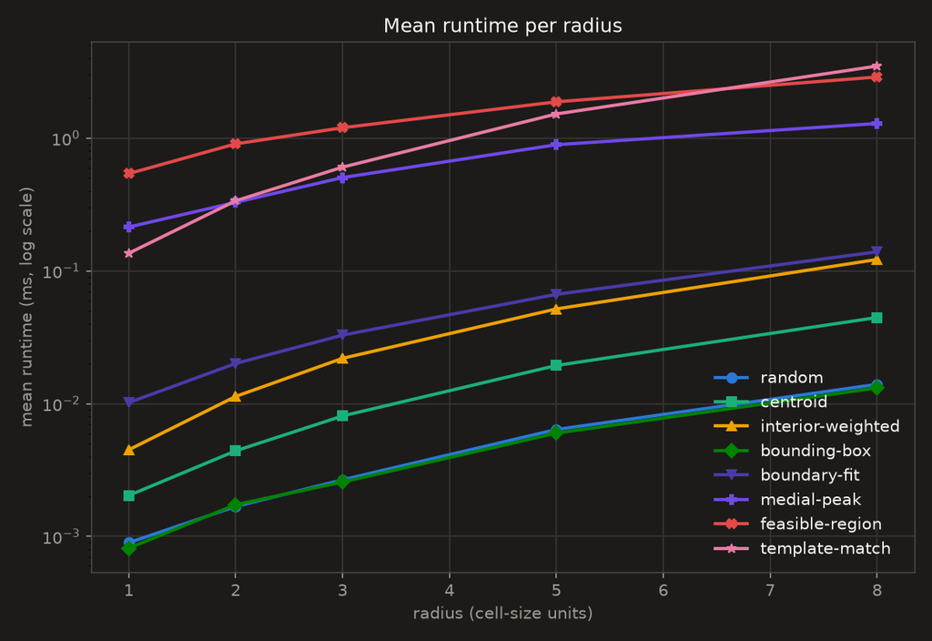

### The trade-off itself

Putting accuracy and speed on the same picture makes the trade-off the point: down-and-to-the-left is better. Random is left off — it’s an order of magnitude worse and would flatten everything else. Feasible-region buys the best accuracy by paying the most time; the interior-weighted centroid is the quiet value pick, nearly free and surprisingly good.

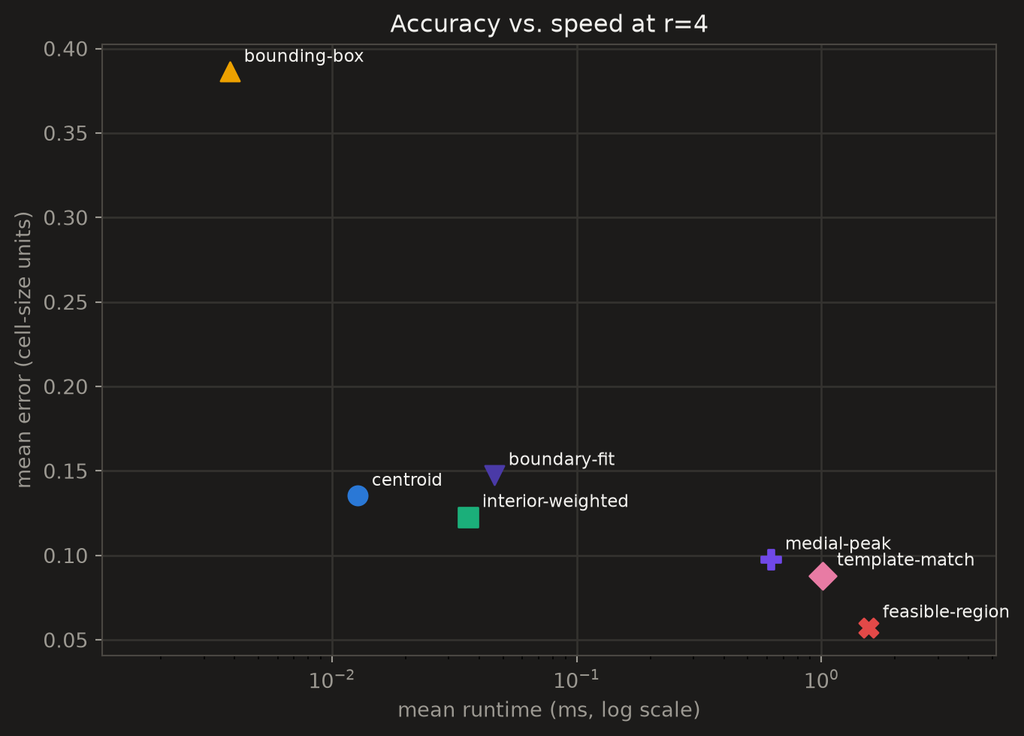

### Head-to-head

Run every idea on the *same* random drops and count how often each one had the single lowest error — its **win rate**. Feasible-region doesn’t just win on average; it wins the most individual rounds too, and its lead widens as the disk grows.

| method | r=1 | r=3 | r=8 |
| --- | --- | --- | --- |
| feasible-region | 39.3% | 43.6% | 51.4% |
| medial-peak | 27.5% | 27.9% | 21.3% |
| template-match | 17.9% | 10.2% | 17.9% |
| interior-weighted | 7.6% | 7.0% | 5.5% |
| boundary-fit | 2.6% | 6.7% | 2.1% |
| centroid | 2.6% | 4.2% | 1.4% |
| bounding-box | 2.6% | 0.3% | 0.4% |

## How good is “best”? A hard floor

Here’s the part I find most satisfying. Feasible-region isn’t just the best idea *I tried* — there’s a limit no algorithm can cross, and it lands almost on top of it.

**Why a floor exists.** The rule from center to colored squares is fixed and the true center is uniformly random, so after seeing the squares, the center is uniformly random over exactly that pocket of still-possible centers from idea 8. No estimator can do better than aiming at the best single point of that pocket, averaged over every observation. That expected distance is a hard floor — the best *any* method could ever achieve.